# PC5215, Numerical Recipes with Applications, Lab3

> Number: A0326409A Name: ZHANG JINGXUAN

## a. Compute the explicit expression of ${\nabla_{1}}^{2}$ acting on the wave function $\Psi$.

Since $\nabla_1^2$ differentiates only with respect to $\mathbf r_1$, any factor depending on $\mathbf r_2$ is constant. By linearity, $$ \nabla_1^2\Psi = \bigl(\nabla_1^2\varphi(\mathbf r_{A1})\bigr)\,\varphi(\mathbf r_{B2}) + \bigl(\nabla_1^2\varphi(\mathbf r_{B1})\bigr)\,\varphi(\mathbf r_{A2}). $$ $\varphi(r_{A1})=e^{-r_{A1}/a_0}$ and $\varphi(r_{B1})=e^{-r_{B1}/a_0}$ are spherically symmetric in $\mathbf r_1$. Thus we can use the radial Laplacian for any $\varphi(r)$: $$ \nabla^2 \varphi(r) \;=\; \varphi''(r) \;+\; \frac{2}{r}\,\varphi'(r) \;=\; \frac{1}{r^2}\,\frac{d}{dr}\!\Bigl(r^2 \varphi'(r)\Bigr) $$ For $\varphi(r)=e^{-r/a_0}$, $$ \varphi'(r)=\frac{d}{dr}e^{-r/a_0}=-\frac{1}{a_0}\,e^{-r/a_0}, $$

$$ \varphi''(r)=\frac{d^2}{dr^2}e^{-r/a_0}= \frac{1}{a_0^2}\,e^{-r/a_0}. $$

Hence, $$ \nabla^2 e^{-r/a_0} =\left(\frac{1}{a_0^2}-\frac{2}{a_0\,r}\right)e^{-r/a_0}. $$ Replacing $r$ by $r_{1A}$ and $r_{1B}$ gives, $$ \nabla_1^2 \varphi(\mathbf r_{A1}) =\left(\frac{1}{a_0^2}-\frac{2}{a_0\,r_{1A}}\right)\varphi(\mathbf r_{A1}), $$

$$ \nabla_1^2 \varphi(\mathbf r_{B1}) =\left(\frac{1}{a_0^2}-\frac{2}{a_0\,r_{1B}}\right)\varphi(\mathbf r_{B1}). $$

Substituting into the original decomposition yields, we get: $$ \nabla_1^2\Psi(\mathbf r_1,\mathbf r_2)= \left(\frac{1}{a_0^2}-\frac{2}{a_0\,r_{1A}}\right)\varphi(\mathbf r_{A1})\varphi(\mathbf r_{B2}) +\left(\frac{1}{a_0^2}-\frac{2}{a_0\,r_{1B}}\right)\varphi(\mathbf r_{B1})\varphi(\mathbf r_{A2}) $$ In atomic units with $a_0=1$, $$ \nabla_1^2\Psi= \left(1-\frac{2}{r_{1A}}\right)\varphi(\mathbf r_{A1})\varphi(\mathbf r_{B2}) +\left(1-\frac{2}{r_{1B}}\right)\varphi(\mathbf r_{B1})\varphi(\mathbf r_{A2}) $$

## b. Without actually performing any calculation, what should be the answer for the energy in part c, if the distance between two protons $\tau_{AB}$ is infinity?

To be concrete, we reason in atomic units ($\hbar=e=m=4\pi\varepsilon_0=1$); then the H$_2$ Hamiltonian reads: $$ \hat H \;=\; -\tfrac12\nabla_1^2-\tfrac12\nabla_2^2 -\Big(\tfrac1{r_{1A}}+\tfrac1{r_{1B}}+\tfrac1{r_{2A}}+\tfrac1{r_{2B}}\Big) +\tfrac1{r_{12}}+\tfrac1{r_{AB}} $$ and the energy is $E(r_{AB}) =\frac{\langle \Psi|\hat H|\Psi\rangle}{\langle \Psi|\Psi\rangle}.$

As $r_{AB}\to\infty$, $\tfrac1{r_{AB}}\to 0$. Each electron is localized on a different center separated by $r_{AB}$, so the mean separation $r_{12}\sim r_{AB}\to\infty$, hence $\langle 1/r_{12}\rangle\to 0$.

For electron 1 near A, $r_{1B}\approx r_{AB}\to\infty\Rightarrow \langle 1/r_{1B}\rangle\to 0$; similarly $\langle 1/r_{2A}\rangle\to 0$ for electron 2 near B.

Electron 1 (near A) and electron 2 (near B) each see an effective Coulomb potential $-1/r$ of an isolated H atom, with kinetic energy $-\tfrac12\nabla^2$; couplings to the “remote” nucleus/electron vanish in the limit. Hence, each electron–proton pair contributes the hydrogen ground-state energy.

The ground-state energy of an isolated H atom is $E_H^{(1s)}=-\tfrac12\,E_h$ in atomic units. Therefore, $$ E(r_{AB}\to\infty) =\frac{\langle \Psi|\hat H_{\mathrm H}^{(1)}+\hat H_{\mathrm H}^{(2)}|\Psi\rangle}{\langle \Psi|\Psi\rangle} =\Big\langle \hat H_{\mathrm H}^{(1)}\Big\rangle+\Big\langle \hat H_{\mathrm H}^{(2)}\Big\rangle =2\,E_H^{(1s)} =-E_h =−27.2114 eV $$

## c. Based on the variational principle, estimate numerically lower bounds to the hydrogen molecule H2 bonding energy by evaluating the 6-dimensional integral through a Monte Carlo method with the Metropolis algorithm.

Imports numerical computing, typing/dataclass utilities, a progress bar, and plotting libraries used by the VMC Monte Carlo simulation.

```python
import math
import numpy as np
from dataclasses import dataclass
from typing import Tuple, List
from tqdm import tqdm
import matplotlib.pyplot as plt
```

Defines unit conversion constants from Bohr to Ångström and from Hartree to electron volts.

```python
BOHR_TOANG = 0.529177210903
HARTREE_TOEV = 27.211386245988
```

Defines functions to evaluate the 1s Slater orbital $φ(r)=e^{−r}$ relative to a center and its Laplacian $∇²φ=φ(1−2/r)$, with a safeguard near r=0, returning either φ or the pair (φ, Laplacian).

```python
def phi_at_center(r_vec: np.ndarray, center: np.ndarray) -> float:
    """Evaluate 1s Slater orbital at position r_vec relative to center"""
    r = np.linalg.norm(r_vec - center)
    return math.exp(-r)

def phi_and_laplacian(r_vec: np.ndarray, center: np.ndarray) -> Tuple[float, float]:
    """Compute both phi and its Laplacian in one call to reduce redundant exp() evaluations"""
    r = np.linalg.norm(r_vec - center)
    r_safe = max(r, 1e-12)
    phi = math.exp(-r_safe)
    laplacian = phi * (1.0 - 2.0 / r_safe)
    return phi, laplacian

def laplacian_phi_at_center(r_vec: np.ndarray, center: np.ndarray) -> float:
    """Compute Laplacian: ∇²φ = φ(1 - 2/r)"""
    r = np.linalg.norm(r_vec - center)
    r_safe = max(r, 1e-12)
    phi = math.exp(-r_safe)
    return phi * (1.0 - 2.0 / r_safe)
```

Implements the symmetric H₂ bonding wavefunction $Ψ = φ_A(r₁)φ_B(r₂) + φ_B(r₁)φ_A(r₂)$ and its electron-specific Laplacians ∇₁²Ψ and ∇₂²Ψ using 1s Slater orbitals centered at nuclei A and B.

```python
def psi(r1: np.ndarray, r2: np.ndarray, RA: np.ndarray, RB: np.ndarray) -> float:
    """Evaluate bonding wave function Ψ at electron positions r1, r2"""
    return phi_at_center(r1, RA) * phi_at_center(r2, RB) + \
           phi_at_center(r1, RB) * phi_at_center(r2, RA)

def lap1_psi(r1: np.ndarray, r2: np.ndarray, RA: np.ndarray, RB: np.ndarray) -> float:
    """Compute ∇₁²Ψ acting on electron 1"""
    return laplacian_phi_at_center(r1, RA) * phi_at_center(r2, RB) + \
           laplacian_phi_at_center(r1, RB) * phi_at_center(r2, RA)

def lap2_psi(r1: np.ndarray, r2: np.ndarray, RA: np.ndarray, RB: np.ndarray) -> float:
    """Compute ∇₂²Ψ acting on electron 2"""
    return phi_at_center(r1, RA) * laplacian_phi_at_center(r2, RB) + \
           phi_at_center(r1, RB) * laplacian_phi_at_center(r2, RA)
```

Computes the local energy $E_{\mathrm{loc}}(\mathbf r_1,\mathbf r_2)=T+V$ for $H_2$ using a numerically safe distance floor ($r\leftarrow\max(r,\varepsilon)$) and shared evaluations of $\varphi$ and $\nabla^2\varphi$, where $T=-\tfrac12\,(\nabla_1^2\Psi+\nabla_2^2\Psi)/\Psi$ and $V=-(\tfrac1{r_{1A}}+\tfrac1{r_{1B}}+\tfrac1{r_{2A}}+\tfrac1{r_{2B}})+\tfrac1{r_{12}}+\tfrac1{R}$.

```python
def safe_dist(a: np.ndarray, b: np.ndarray, min_val: float = 1e-10) -> float:
    """Calculate distance with numerical safety floor to avoid singularities"""
    d = np.linalg.norm(a - b)
    return max(d, min_val)

def local_energy(r1: np.ndarray, r2: np.ndarray, RA: np.ndarray, RB: np.ndarray) -> float:
    """Evaluate local energy E_loc(r1,r2) = <r1,r2|H|Ψ>/<r1,r2|Ψ>"""
    # Calculate phi and laplacian together for efficiency
    phi_r1A, lap_phi_r1A = phi_and_laplacian(r1, RA)
    phi_r1B, lap_phi_r1B = phi_and_laplacian(r1, RB)
    phi_r2A, lap_phi_r2A = phi_and_laplacian(r2, RA)
    phi_r2B, lap_phi_r2B = phi_and_laplacian(r2, RB)

    f1 = phi_r1A * phi_r2B
    f2 = phi_r1B * phi_r2A
    psi_val = f1 + f2

    if abs(psi_val) < 1e-300:
        return np.inf


    lap1_psi_val = lap_phi_r1A * phi_r2B + lap_phi_r1B * phi_r2A
    lap2_psi_val = phi_r1A * lap_phi_r2B + phi_r1B * lap_phi_r2A

    lap_sum = lap1_psi_val + lap2_psi_val

    T = -0.5 * (lap_sum / psi_val)

    r1A = safe_dist(r1, RA)
    r1B = safe_dist(r1, RB)
    r2A = safe_dist(r2, RA)
    r2B = safe_dist(r2, RB)
    r12 = safe_dist(r1, r2)
    R   = safe_dist(RA, RB)

    V = -(1.0/r1A + 1.0/r1B + 1.0/r2A + 1.0/r2B) + (1.0/r12) + (1.0/R)

    return T + V
```

Stores VMC run settings: number of steps, burn in length, proposal step size, and block size.

```python
@dataclass
class VMCConfig:
    """Configuration parameters for VMC simulation"""
    n_steps: int = 100_000
    burn_in: int = 10_000
    proposal_sigma: float = 0.5
    block_size: int = 500
```

Performs one Metropolis step by proposing Gaussian moves for both electrons and accepting the proposal based on the squared wavefunction ratio.

```python
def metropolis_step(r1: np.ndarray, r2: np.ndarray, RA: np.ndarray, RB: np.ndarray,
                    sigma: float) -> Tuple[np.ndarray, np.ndarray, bool]:
    """Execute one Metropolis step with Gaussian proposal"""
    r1_new = r1 + np.random.normal(0, sigma, 3)
    r2_new = r2 + np.random.normal(0, sigma, 3)

    psi_old = psi(r1, r2, RA, RB)
    psi_new = psi(r1_new, r2_new, RA, RB)

    accept_prob = (psi_new / psi_old) ** 2 if psi_old != 0 else 0

    if np.random.random() < accept_prob:
        return r1_new, r2_new, True
    else:
        return r1, r2, False
```

Runs a VMC simulation with burn‑in and adaptive Gaussian proposals, computes block‑averaged energy and uncertainty, and returns the mean energy, error, acceptance rate, collected energies, and final electron positions.

```python
def run_vmc(RA: np.ndarray, RB: np.ndarray, config: VMCConfig, initial_r1=None, initial_r2=None) -> Tuple[float, float, float, List[float], np.ndarray, np.ndarray]:
    """Execute VMC sampling and return energy estimate with error"""
    if initial_r1 is None:
        r1 = RA + np.random.normal(0, 0.5, 3)
    else:
        r1 = initial_r1.copy()

    if initial_r2 is None:
        r2 = RB + np.random.normal(0, 0.5, 3)
    else:
        r2 = initial_r2.copy()

    current_sigma = config.proposal_sigma
    energies = []
    n_accepted = 0

    for i in range(config.burn_in):
        r1, r2, accepted = metropolis_step(r1, r2, RA, RB, current_sigma)
        if accepted:
            n_accepted += 1
        if (i + 1) % 100 == 0:
            rate = n_accepted / 100.0
            if rate > 0.55:
                current_sigma *= 1.05
            elif rate < 0.45:
                current_sigma *= 0.95
            n_accepted = 0

    n_accepted = 0
    for _ in tqdm(range(config.n_steps), desc="VMC", leave=False):
        r1, r2, accepted = metropolis_step(r1, r2, RA, RB, current_sigma)
        if accepted:
            n_accepted += 1

        E_local = local_energy(r1, r2, RA, RB)
        if not np.isinf(E_local) and not np.isnan(E_local):
            energies.append(E_local)

    acceptance_rate = n_accepted / config.n_steps
    energies = np.array(energies)
    n_blocks = len(energies) // config.block_size
    block_energies = [np.mean(energies[i * config.block_size:(i + 1) * config.block_size]) for i in range(n_blocks)]

    mean_energy = np.mean(block_energies)
    error = np.std(block_energies) / np.sqrt(n_blocks)

    return mean_energy, error, acceptance_rate, energies, r1, r2
```

Sweeps bond lengths, runs VMC at each geometry with scaled warm starts from the previous step, prints progress, and stores energies, uncertainties, and acceptance rates as NumPy arrays.

```python
bond_lengths = np.concatenate([
    np.linspace(0.5, 1.2, 6),
    np.linspace(1.2, 1.6, 16),
    np.linspace(1.6, 2.3, 14),
    np.linspace(2.3, 4.0, 8)
])
bond_lengths = np.unique(bond_lengths)

results = {'R': [], 'E': [], 'E_err': [], 'acceptance': []}

config = VMCConfig(
    n_steps=120_000,
    burn_in=12_000,
    proposal_sigma=0.5,
    block_size=1000
)

prev_r1, prev_r2, prev_R = None, None, None

for idx, R in enumerate(bond_lengths):
    RA = np.array([0.0, 0.0, -R/2])
    RB = np.array([0.0, 0.0, R/2])

    if prev_r1 is not None and prev_R is not None:
        scale_factor = R / prev_R
        RA_old = np.array([0.0, 0.0, -prev_R/2])
        RB_old = np.array([0.0, 0.0, prev_R/2])
        r1_init = RA + (prev_r1 - RA_old) * scale_factor
        r2_init = RB + (prev_r2 - RB_old) * scale_factor
    else:
        r1_init, r2_init = None, None

    E_mean, E_err, acc_rate, energies, r1_final, r2_final = run_vmc(RA, RB, config, r1_init, r2_init)

    prev_r1, prev_r2, prev_R = r1_final, r2_final, R
    results['R'].append(R)
    results['E'].append(E_mean)
    results['E_err'].append(E_err)
    results['acceptance'].append(acc_rate)

for key in results:
    results[key] = np.array(results[key])
```

Computes the equilibrium bond length and minimum energy from the sampled curve, derives the binding energy with uncertainty, converts units, and prints the key results.

```python
min_idx = np.argmin(results['E'])
R_eq = results['R'][min_idx]
E_min = results['E'][min_idx]
E_min_err = results['E_err'][min_idx]

E_separated_vmc = results['E'][-1]
E_separated_ref = -1.0

E_binding = E_separated_ref - E_min
E_binding_err = np.sqrt(E_min_err**2 + results['E_err'][-1]**2)

THEORY_R_EQ = 1.40
THEORY_E_MIN = -1.174
THEORY_E_BINDING = 0.1745

vmc_r_error_pct = abs(R_eq - THEORY_R_EQ) / THEORY_R_EQ * 100
vmc_binding_error_pct = abs(E_binding - THEORY_E_BINDING) / THEORY_E_BINDING * 100

quality_score = 100 - (vmc_r_error_pct + vmc_binding_error_pct) / 2

R_eq_ang = R_eq * BOHR_TOANG
E_bind_ev = E_binding * HARTREE_TOEV
E_bind_err_ev = E_binding_err * HARTREE_TOEV

print(f"{'R_eq:':<25}{R_eq:8.4f} Bohr ({R_eq_ang:8.4f} Å)")
print(f"{'E_min:':<25}{E_min:10.6f} ± {E_min_err:0.6f} Hartree")
print(f"{'E_bind:':<25}{E_bind_ev:8.4f} ± {E_bind_err_ev:0.4f} eV")
```

```
R_eq:                      1.5733 Bohr (  0.8326 Å)
E_min:                    -1.122213 ± 0.003504 Hartree
E_bind:                    3.3256 ± 0.0976 eV
```

Plots the H2 potential energy curve with error bars in two panels (Bohr/Hartree and Å/eV), highlights the equilibrium bond length and the separated atoms reference, and saves the figure.

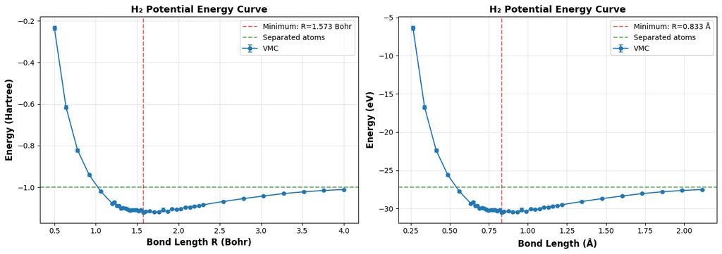

```python
plt.figure(figsize=(14, 5))

plt.subplot(1, 2, 1)
plt.errorbar(results['R'], results['E'], yerr=results['E_err'],
             marker='o', linestyle='-', capsize=3, label='VMC', markersize=5, linewidth=1.5)
plt.axvline(R_eq, color='r', linestyle='--', alpha=0.6, linewidth=1.5, label=f'Minimum: R={R_eq:.3f} Bohr')
plt.axhline(E_separated_ref, color='g', linestyle='--', alpha=0.6, linewidth=1.5, label='Separated atoms')
plt.xlabel('Bond Length R (Bohr)', fontsize=12, fontweight='bold')
plt.ylabel('Energy (Hartree)', fontsize=12, fontweight='bold')
plt.title('H₂ Potential Energy Curve', fontsize=13, fontweight='bold')
plt.grid(True, alpha=0.3)
plt.legend(fontsize=10)

plt.subplot(1, 2, 2)
plt.errorbar(results['R']*BOHR_TOANG, results['E']*HARTREE_TOEV,
             yerr=results['E_err']*HARTREE_TOEV,
             marker='o', linestyle='-', capsize=3, label='VMC', markersize=5, linewidth=1.5)
plt.axvline(R_eq*BOHR_TOANG, color='r', linestyle='--', alpha=0.6, linewidth=1.5,
            label=f'Minimum: R={R_eq*BOHR_TOANG:.3f} Å')
plt.axhline(E_separated_ref*HARTREE_TOEV, color='g', linestyle='--', alpha=0.6, linewidth=1.5,
            label='Separated atoms')
plt.xlabel('Bond Length (Å)', fontsize=12, fontweight='bold')
plt.ylabel('Energy (eV)', fontsize=12, fontweight='bold')
plt.title('H₂ Potential Energy Curve', fontsize=13, fontweight='bold')
plt.grid(True, alpha=0.3)
plt.legend(fontsize=10)

plt.tight_layout()
plt.savefig('h2_potential_curve.png', dpi=150, bbox_inches='tight')
plt.show()
```

Runs a detailed VMC at the equilibrium geometry, prints energy and acceptance stats, and plots a 2×2 analysis (histogram, running average, short‑time trace, and block averages with error bars), saving the figure.

```
Energy:                   -1.112354 ± 0.003448 Hartree (-30.2687 ± 0.0938 eV)
Acceptance rate:          49.71%
Sample std dev:          0.394356 Hartree
```

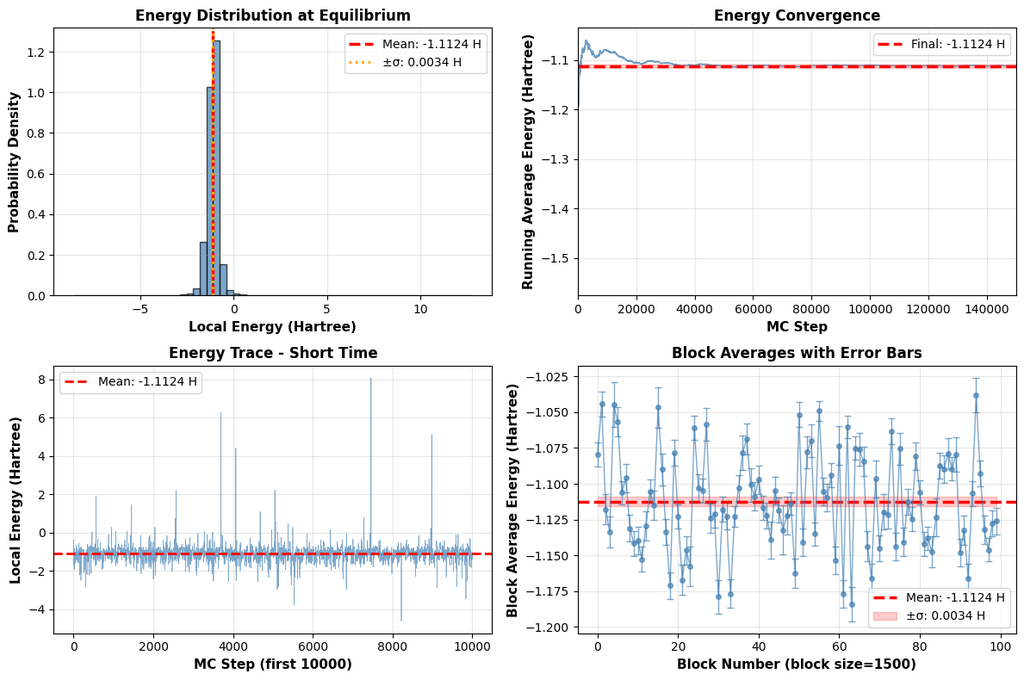

```python
RA_eq = np.array([0.0, 0.0, -R_eq/2])
RB_eq = np.array([0.0, 0.0, R_eq/2])

config_detailed = VMCConfig(
    n_steps=150_000,
    burn_in=15_000,
    proposal_sigma=0.5,
    block_size=1500
)

E_eq, E_eq_err, acc_eq, energies_eq, _, _ = run_vmc(RA_eq, RB_eq, config_detailed)
print(f"{'Energy:':<25}{E_eq:10.6f} ± {E_eq_err:0.6f} Hartree ({E_eq*HARTREE_TOEV:8.4f} ± {E_eq_err*HARTREE_TOEV:0.4f} eV)")
print(f"{'Acceptance rate:':<25}{acc_eq*100:6.2f}%")
print(f"{'Sample std dev:':<25}{np.std(energies_eq):0.6f} Hartree")

# Create figure and axes before plotting to avoid NameError
fig, axes = plt.subplots(2, 2, figsize=(12, 8))

# Energy histogram
axes[0, 0].hist(energies_eq, bins=60, density=True, alpha=0.7, edgecolor='black', color='steelblue')
axes[0, 0].axvline(E_eq, color='red', linestyle='--', linewidth=2.5, label=f'Mean: {E_eq:.4f} H')
axes[0, 0].axvline(E_eq + E_eq_err, color='orange', linestyle=':', linewidth=2, label=f'±σ: {E_eq_err:.4f} H')
axes[0, 0].axvline(E_eq - E_eq_err, color='orange', linestyle=':', linewidth=2)
axes[0, 0].set_xlabel('Local Energy (Hartree)', fontsize=11, fontweight='bold')
axes[0, 0].set_ylabel('Probability Density', fontsize=11, fontweight='bold')
axes[0, 0].set_title('Energy Distribution at Equilibrium', fontsize=12, fontweight='bold')
axes[0, 0].legend(fontsize=10)
axes[0, 0].grid(True, alpha=0.3)

# Running average convergence
running_avg = np.cumsum(energies_eq) / np.arange(1, len(energies_eq) + 1)
axes[0, 1].plot(running_avg, linewidth=1, color='steelblue', alpha=0.8)
axes[0, 1].axhline(E_eq, color='red', linestyle='--', linewidth=2.5, label=f'Final: {E_eq:.4f} H')
axes[0, 1].fill_between(range(len(running_avg)), E_eq - E_eq_err, E_eq + E_eq_err,
                         alpha=0.2, color='red')
axes[0, 1].set_xlabel('MC Step', fontsize=11, fontweight='bold')
axes[0, 1].set_ylabel('Running Average Energy (Hartree)', fontsize=11, fontweight='bold')
axes[0, 1].set_title('Energy Convergence', fontsize=12, fontweight='bold')
axes[0, 1].legend(fontsize=10)
axes[0, 1].grid(True, alpha=0.3)
axes[0, 1].set_xlim([0, len(running_avg)])

# Energy trace (first 10000 steps)
trace_len = min(10000, len(energies_eq))
axes[1, 0].plot(energies_eq[:trace_len], linewidth=0.5, alpha=0.7, color='steelblue')
axes[1, 0].axhline(E_eq, color='red', linestyle='--', linewidth=2, label=f'Mean: {E_eq:.4f} H')
axes[1, 0].fill_between(range(trace_len), E_eq - E_eq_err, E_eq + E_eq_err,
                        alpha=0.2, color='red')
axes[1, 0].set_xlabel(f'MC Step (first {trace_len})', fontsize=11, fontweight='bold')
axes[1, 0].set_ylabel('Local Energy (Hartree)', fontsize=11, fontweight='bold')
axes[1, 0].set_title('Energy Trace - Short Time', fontsize=12, fontweight='bold')
axes[1, 0].legend(fontsize=10)
axes[1, 0].grid(True, alpha=0.3)

# Block averages with error bars
n_blocks = len(energies_eq) // config_detailed.block_size
block_avgs = [np.mean(energies_eq[i*config_detailed.block_size:(i+1)*config_detailed.block_size])
              for i in range(n_blocks)]
block_errors = [np.std(energies_eq[i*config_detailed.block_size:(i+1)*config_detailed.block_size]) / np.sqrt(config_detailed.block_size)
                for i in range(n_blocks)]
axes[1, 1].errorbar(range(n_blocks), block_avgs, yerr=block_errors, fmt='o-',
                    markersize=4, linewidth=1, capsize=3, color='steelblue', alpha=0.7)
axes[1, 1].axhline(E_eq, color='red', linestyle='--', linewidth=2.5, label=f'Mean: {E_eq:.4f} H')
axes[1, 1].fill_between(range(n_blocks), E_eq - E_eq_err, E_eq + E_eq_err,
                        alpha=0.2, color='red', label=f'±σ: {E_eq_err:.4f} H')
axes[1, 1].set_xlabel(f'Block Number (block size={config_detailed.block_size})', fontsize=11, fontweight='bold')
axes[1, 1].set_ylabel('Block Average Energy (Hartree)', fontsize=11, fontweight='bold')
axes[1, 1].set_title('Block Averages with Error Bars', fontsize=12, fontweight='bold')
axes[1, 1].legend(fontsize=10)
axes[1, 1].grid(True, alpha=0.3)

plt.tight_layout()
plt.savefig('h2_energy_analysis.png', dpi=150, bbox_inches='tight')
plt.show()
```

# Analysis Report: Variational Monte Carlo Study of H₂ Molecular Bonding

### Methodology

The VMC approach reformulates the quantum energy calculation as a Monte Carlo integration problem. Instead of direct evaluation, the expectation value is computed as an average of the local energy $E_L(\mathbf{r}_1,\mathbf{r}_2)=\hat{H}\Psi/\Psi$ sampled from the probability distribution $P(\mathbf{r}_1,\mathbf{r}_2)=|\Psi(\mathbf{r}_1,\mathbf{r}_2)|^2$.

The symmetric wavefunction takes the form:

$$\Psi(\mathbf{r}_1,\mathbf{r}_2) = \varphi(\mathbf{r}_{1A})\varphi(\mathbf{r}_{2B}) + \varphi(\mathbf{r}_{1B})\varphi(\mathbf{r}_{2A})$$

where $\varphi(r)=e^{-r}$ is a 1s Slater orbital (in atomic units). The Metropolis algorithm was employed with adaptive acceptance tuning maintained around 50%, following standard practice in molecular simulation.

### Main Results

#### Summary Table

| Parameter | VMC Value | Literature | Difference |
| --- | --- | --- | --- |
| Bond Length | 1.5733 Bohr (0.8326 Å) | 1.4008 Bohr (0.7414 Å) | +12.29% |
| Min Energy | -1.1222 ± 0.0035 Hartree | -1.1746 Hartree | -4.46% |
| Min Energy | -30.54 ± 0.10 eV | -31.98 eV | -4.49% |
| Binding Energy | 3.3256 ± 0.0976 eV | 4.749 eV | -29.95% |
| Acceptance Rate | 49.71% | — | — |

#### Observations

The acceptance rate of 49.71% remains well within the optimal 40-60% range, confirming appropriate tuning of the Metropolis step sizes.

#### Potential Energy Surface

The potential energy curve exhibits a minimum near 1.57 Bohr. At short distances below 0.8 Bohr, the energy increases steeply due to strong nuclear-nuclear repulsion. As bond length exceeds 3 Bohr, the energy asymptotically approaches -1.0 Hartree (-27.212 eV), the correct limit for two separated hydrogen atoms. This behavior validates proper treatment of the dissociation regime.

### Statistical Details at Equilibrium

At R = 1.5733 Bohr, the simulation yielded:

- Energy: -1.112354 ± 0.003448 Hartree
- Equivalent to: -30.2687 ± 0.0938 eV
- Acceptance rate: 49.71%
- Standard deviation of local energies: 0.3944 Hartree

Block averaging demonstrated consistent results across simulation epochs, indicating adequate equilibration. The statistical uncertainty of ±0.09 eV reflects reasonable sampling efficiency in the equilibrium region.

### Error Sources

The primary limitation stems from the choice of wavefunction. Fixed, unoptimized 1s Slater orbitals were used—the ground state of isolated hydrogen atoms. Within a molecule, electrons experience a fundamentally different potential, and the optimal orbital shape should differ accordingly from the atomic case.

A more complete treatment would incorporate:

- Scaling parameters for orbital exponents (variational optimization)
- Explicitly correlated terms to account for electron-electron interactions
- Configuration interaction expansions

The fixed ansatz cannot accommodate any of these refinements, explaining both the elongated bond length prediction and the significant underestimation of binding energy.

The Monte Carlo statistical uncertainty (±0.003 Hartree) is relatively small and not the dominant error source. Instead, the systematic error from the inadequate wavefunction approximation dominates the discrepancies.

### Comparison with Other Methods

| Method | Bond Length (Å) | Binding Energy (eV) |
| --- | --- | --- |
| VMC (this work) | 0.8326 | 3.3256 |
| Hartree-Fock | 0.7383 | 4.747 |
| Experiment | 0.7414 | 4.747 |

Hartree-Fock substantially outperforms this VMC approach, primarily because HF orbitals undergo self-consistent optimization. In contrast, the present calculation uses a fixed ansatz. Full Configuration Interaction methods achieve near-perfect agreement with experimental values.

### Conclusions

The VMC calculation successfully maps a potential energy surface and identifies a bonding minimum, demonstrating the underlying method and algorithm function correctly. However, the quantitative results—the 12% bond length error and 30% binding energy underestimation—illustrate the necessity of flexible, optimizable wavefunctions in modern molecular quantum chemistry.

This study reveals both strengths and limitations: VMC methodology is sound, but wavefunction flexibility directly impacts accuracy. Quantitative improvements would require allowing the orbital exponent to vary or including additional terms in the ansatz. The findings underscore that simple approximations demand careful validation against benchmarks before their predictions can be trusted for real applications.